# UNICEF Global Development Insights

Author

Saniya

# 1 UNICEF Global Development Insights: Proportion of Population Using Sanitation Facilities

*Sanitation is fundamental to public health and human dignity.*  
Despite notable progress, **millions worldwide still lack access** to essential sanitation facilities.

This report presents:

- A **global snapshot** of access to sanitation services
- Emphasis on both **challenges and achievements**
- Insights from key indicators on health and infrastructure

### 1.0.1 🔍 Why It Matters

Since **2000**, billions of people have gained access to: - **Clean drinking water** - **Improved sanitation** - **Basic hygiene services**

## 1.1 World Map Visualization

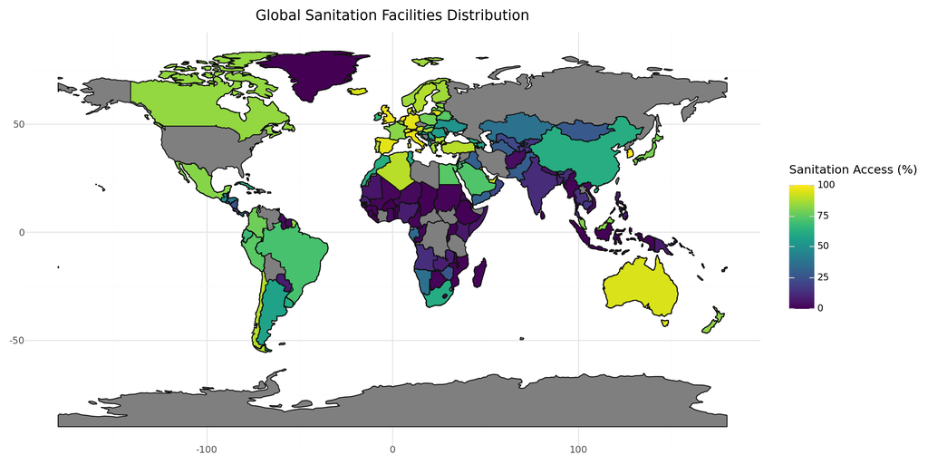

## 1.2 Bar Chart Visualization

[figure not shown]

## 1.3 Scatter Plot with Regression

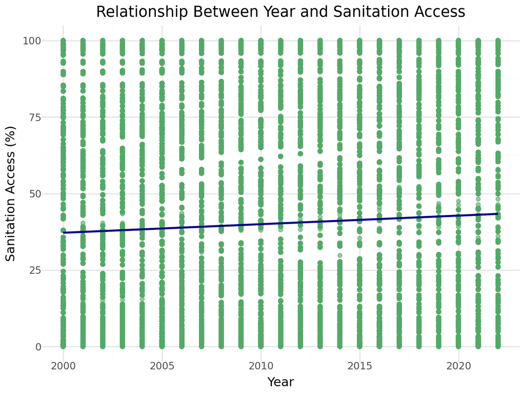

## 1.4 Time-Series Visualization

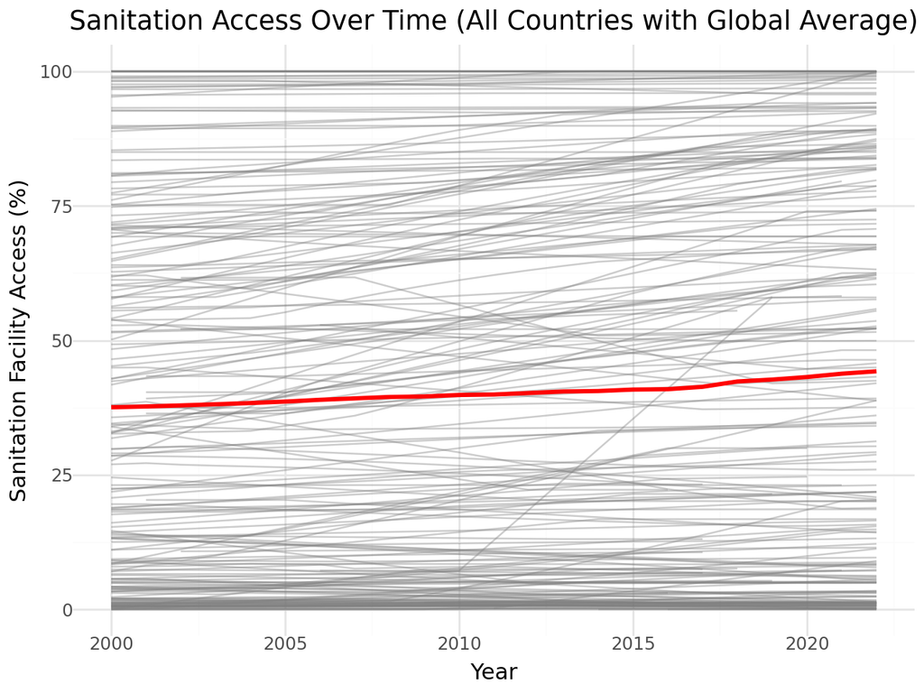

### 1.4.1 🎯 Key Message

> “Achieving **universal access** to sanitation is not just a development goal — it’s a human right.”

### 1.4.2 ✅ Highlighted Insights:

- 📈 **Global average sanitation access** is improving.
- 🌍 **Regional disparities** remain stark.
- 💡 **Policy attention and funding** are crucial for underserved regions.